# Laboratorio 2 en R: Regresión multivariada, especificación y estimación

Kerry Loaiza Marín

[figure not shown]

En este laboratorio se utilizará el siguiente archivo:

Download LONDON.dat

# 1 Gráfico de dispersión entre pares de variables

**Ejemplo 1:** Importe los datos del archivo london.dat, utilizados en el laboratorio pasado. Suponga que, con base en estos datos, está interesado en conocer los determinantes de la porción del presupuesto que las familias dedican al consumo de alcohol.

Un primer examen útil suele involucrar un gráfico de la variable dependiente contra candidatas a variables explicativas. Esto da una idea del tipo de asociación (positiva o negativa) que tienen las variables.

Algunas variables candidatas a explicativas de walc podrían ser totexp, age y nk. Realice un gráfico de dispersión de totexp contra walc.

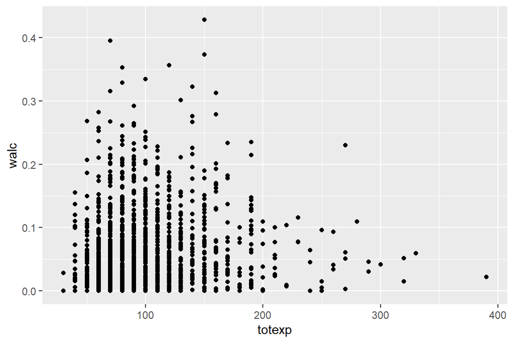

```r
library(ggplot2)
datos <-  read.table("LONDON.dat", header = TRUE)
attach(datos)

ggplot(data = datos, mapping = aes(x = totexp, y = walc)) +
  geom_point()
```

# 2 Estimación de regresión lineal

Suponga que se desea estimar el siguiente modelo de regresión multivariada:

$walc = \beta_{0} + \beta_{1}\ln(totexp) + \beta_{2}age + \beta_{3}nk + \varepsilon$

```r
#La función lm significa "linear model" del paquete stats y está integrada en el R base.
#Generamos el objeto modelo_1 que contendrá la estimación

modelo_1 <- lm(formula =  walc ~ log(totexp) + age + nk, data = datos)
```

El objeto “modelo_1” contiene una lista que es el resultado de la función **lm**. Esta lista incluye varios objetos, los más importantes son los llamados: “coefficients” guarda los coeficientes, “residuals” guarda los residuos de la regresión y “fitted.values” que guarda los valores para la variable dependiente que el modelo pronosticaría.

Dado que es una lista, cada uno de estos elementos se puede acceder, utilizar y modificar. Además, algunas funciones pueden tomar este objeto y producir resultados útiles. Por ejemplo, la función **summary** sobre el objeto modelo_1 brindaría un resumen de los resultados de la regresión. Otras funciones generales son **coefficients**, **fitted.values** y **residuals** para extraer diversos objetos o características del modelo generado por la función **lm**. Las funciones genéricas **coef** y **vcov** extraen los coeficientes y la matriz de varianza y covarianza de los errores respectivamente. **predict.lm** se usa para predicción (se necesita información de los regresores fuera de muestra para la predicción), incluidos intervalos de confianza; la función **confint** permite obtener intervalos de confianza para los coeficientes estimados.

```r
summary(modelo_1)
```

```
##
## Call:
## lm(formula = walc ~ log(totexp) + age + nk, data = datos)
##
## Residuals:
##      Min       1Q   Median       3Q      Max
## -0.09926 -0.04362 -0.01665  0.02807  0.36451
##
## Coefficients:
##               Estimate Std. Error t value Pr(>|t|)
## (Intercept)  0.0075574  0.0200936   0.376    0.707
## log(totexp)  0.0280816  0.0044098   6.368 2.58e-10 ***
## age         -0.0014409  0.0002186  -6.591 6.16e-11 ***
## nk          -0.0135191  0.0034139  -3.960 7.87e-05 ***
## ---
## Signif. codes:  0 '***' 0.001 '**' 0.01 '*' 0.05 '.' 0.1 ' ' 1
##
## Residual standard error: 0.06222 on 1415 degrees of freedom
## Multiple R-squared:  0.05394,    Adjusted R-squared:  0.05194
## F-statistic: 26.89 on 3 and 1415 DF,  p-value: < 2.2e-16
```

```r
#Accedemos a parte de los residuos de la regresión con la indexación de la lista

#primera forma
head(modelo_1$residuals)
```

```
##           1           2           3           4           5           6
## -0.03039775  0.15961514 -0.03081826  0.02110225  0.03396758  0.17034814
```

```r
#segunda forma
head(modelo_1[[2]])
```

```
##           1           2           3           4           5           6
## -0.03039775  0.15961514 -0.03081826  0.02110225  0.03396758  0.17034814
```

```r
#Predicción del modelo e intervalos de confianza de la predicción y de los coeficientes
prediccion_modelo_1<-predict.lm(modelo_1, se.fit = TRUE, level = 0.95, interval = c("confidence"))

head(prediccion_modelo_1$fit)
```

```
##          fit        lwr        upr
## 1 0.05659775 0.05135028 0.06184521
## 2 0.07098486 0.06553495 0.07643477
## 3 0.07171826 0.06379954 0.07963699
## 4 0.05659775 0.05135028 0.06184521
## 5 0.05803242 0.05142170 0.06464314
## 6 0.06755186 0.06137878 0.07372493
```

```r
int_confianza_modelo_1<- confint(modelo_1, level = 0.95)

int_confianza_modelo_1
```

```
##                    2.5 %       97.5 %
## (Intercept) -0.031858955  0.046973773
## log(totexp)  0.019431199  0.036731978
## age         -0.001869723 -0.001012011
## nk          -0.020215961 -0.006822187
```

**Ejercicio 1:** utilice los datos del archivo “LONDON.dat” para hacer lo siguiente:

1. Una regresión de *wfood* en una constante y *log(totexp)*, *age* y *nk*.
2. Obtenga los coeficientes estimados, el $R^{2}$ y el estadístico *F* de la regresión.
3. Cree una matriz llamada “varcov” que contenga las varianzas y covarianzas de la regresión.

# 3 Gráfico de residuos MCO

El gráfico de los residuos de la regresión es importante para notar posibles errores sistemáticos que indiquen un problema en la especificación utilizada. Vamos a realizar un gráfico con los residuos y otro con los valores observados y ajustados de la regresión para la variable *walc*.

```r
#Primero se cree un objeto con los datos a graficar
#La función cbind pega columnas, luego la función names asigna nombres a las columnas, se debe transformar de matriz a data.frame

datos_regresion <- cbind(datos$walc, fitted.values(modelo_1), resid(modelo_1))
datos_regresion<-as.data.frame(datos_regresion)
names(datos_regresion)<-c("walc", "fitted", "residuos")

head(datos_regresion)
```

| walc | fitted | residuos |
| --- | --- | --- |
| 0.0262 | 0.0565977 | -0.0303977 |
| 0.2306 | 0.0709849 | 0.1596151 |
| 0.0409 | 0.0717183 | -0.0308183 |
| 0.0777 | 0.0565977 | 0.0211023 |
| 0.0920 | 0.0580324 | 0.0339676 |
| 0.2379 | 0.0675519 | 0.1703481 |

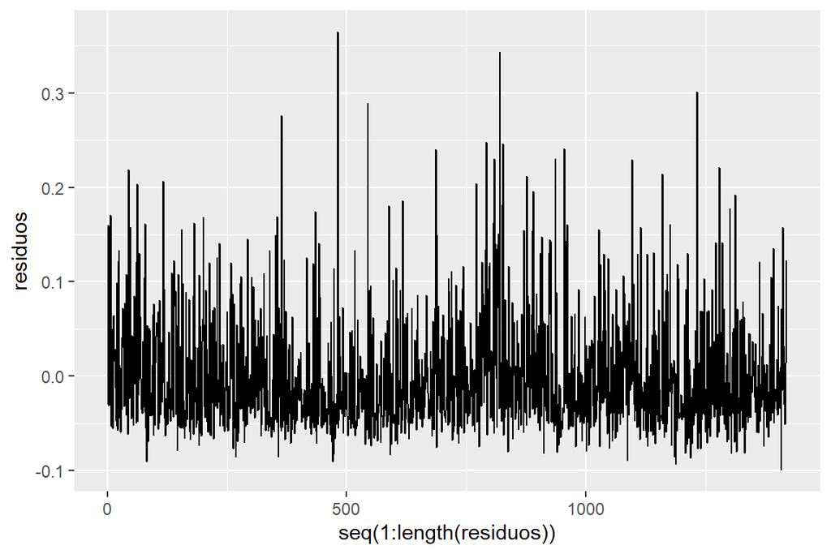

```r
#Primero el gráfico de los residuos
ggplot(data = datos_regresion,
mapping = aes(x = seq(1:length(residuos)),
y = residuos)) +
geom_line()
```

[figure not shown]

```r
#Segundo el gráfico de los valores observados y ajustados
#Se transforman los datos para su uso
library(tidyr)
datos_regresion1<-datos_regresion %>%
  pivot_longer(  cols = c(1,2),
  names_to = "walc_names",
  values_to = "walc_regression"
  )

ggplot(data = datos_regresion1,
mapping = aes(x = seq(1:length(residuos)),
y = walc_regression, color = as.factor(walc_names))) +
geom_line()+
  scale_color_manual( values=c('#009E73', '#D55E00'), name='walc', labels=c('Observado', 'Predicho') )
```

# 4 Pronóstico con la regresión estimada

Como vimos, obtener la predicción dentro de muestra de una regresión es simple en R. Ahora, con los mismos datos del ejercicio anterior realice los siguiente.

**Tarea 3:** Escriba un programa que:

1. Efectúe un pronóstico dentro de muestra para la serie *wfood*.
2. Construya un intervalo de confianza del 95% para la serie pronosticada.
3. Grafique la serie de pronóstico con los intervalos de confianza.